# Assignment2_yli130

Yanxi Li

10/2/2020

# The process how to classify the customer :

1 : import data and the related library. 2 : convert correct format to the data. 3 : split data into 60% Training and 40% Validation sets. 4 : normalize the data. 5 : evaluate the model (confusion matrix). 6 : predict the new customer with the model.

# Step 1 : Import data

```r
getwd()
```

```
## [1] "C:/Users/yanxi/OneDrive/Desktop"
```

```r
setwd("C:\\Users\\yanxi\\OneDrive\\Desktop\\")
bank_data <- read.csv("UniversalBank.csv")
my_bank_data <- bank_data[,-c(1,5)]   # remove ID & ZIPCODE columns
colnames(my_bank_data)
```

```
##  [1] "Age"                "Experience"         "Income"
##  [4] "Family"             "CCAvg"              "Education"
##  [7] "Mortgage"           "Personal.Loan"      "Securities.Account"
## [10] "CD.Account"         "Online"             "CreditCard"
```

```r
summary(my_bank_data)
```

```
##       Age          Experience       Income           Family
##  Min.   :23.00   Min.   :-3.0   Min.   :  8.00   Min.   :1.000
##  1st Qu.:35.00   1st Qu.:10.0   1st Qu.: 39.00   1st Qu.:1.000
##  Median :45.00   Median :20.0   Median : 64.00   Median :2.000
##  Mean   :45.34   Mean   :20.1   Mean   : 73.77   Mean   :2.396
##  3rd Qu.:55.00   3rd Qu.:30.0   3rd Qu.: 98.00   3rd Qu.:3.000
##  Max.   :67.00   Max.   :43.0   Max.   :224.00   Max.   :4.000
##      CCAvg          Education        Mortgage     Personal.Loan
##  Min.   : 0.000   Min.   :1.000   Min.   :  0.0   Min.   :0.000
##  1st Qu.: 0.700   1st Qu.:1.000   1st Qu.:  0.0   1st Qu.:0.000
##  Median : 1.500   Median :2.000   Median :  0.0   Median :0.000
##  Mean   : 1.938   Mean   :1.881   Mean   : 56.5   Mean   :0.096
##  3rd Qu.: 2.500   3rd Qu.:3.000   3rd Qu.:101.0   3rd Qu.:0.000
##  Max.   :10.000   Max.   :3.000   Max.   :635.0   Max.   :1.000
##  Securities.Account   CD.Account         Online         CreditCard
##  Min.   :0.0000     Min.   :0.0000   Min.   :0.0000   Min.   :0.000
##  1st Qu.:0.0000     1st Qu.:0.0000   1st Qu.:0.0000   1st Qu.:0.000
##  Median :0.0000     Median :0.0000   Median :1.0000   Median :0.000
##  Mean   :0.1044     Mean   :0.0604   Mean   :0.5968   Mean   :0.294
##  3rd Qu.:0.0000     3rd Qu.:0.0000   3rd Qu.:1.0000   3rd Qu.:1.000
##  Max.   :1.0000     Max.   :1.0000   Max.   :1.0000   Max.   :1.000
```

```r
head(my_bank_data)
```

```
##   Age Experience Income Family CCAvg Education Mortgage Personal.Loan
## 1  25          1     49      4   1.6         1        0             0
## 2  45         19     34      3   1.5         1        0             0
## 3  39         15     11      1   1.0         1        0             0
## 4  35          9    100      1   2.7         2        0             0
## 5  35          8     45      4   1.0         2        0             0
## 6  37         13     29      4   0.4         2      155             0
##   Securities.Account CD.Account Online CreditCard
## 1                  1          0      0          0
## 2                  1          0      0          0
## 3                  0          0      0          0
## 4                  0          0      0          0
## 5                  0          0      0          1
## 6                  0          0      1          0
```

```r
str(my_bank_data)
```

```
## 'data.frame':    5000 obs. of  12 variables:
##  $ Age               : int  25 45 39 35 35 37 53 50 35 34 ...
##  $ Experience        : int  1 19 15 9 8 13 27 24 10 9 ...
##  $ Income            : int  49 34 11 100 45 29 72 22 81 180 ...
##  $ Family            : int  4 3 1 1 4 4 2 1 3 1 ...
##  $ CCAvg             : num  1.6 1.5 1 2.7 1 0.4 1.5 0.3 0.6 8.9 ...
##  $ Education         : int  1 1 1 2 2 2 2 3 2 3 ...
##  $ Mortgage          : int  0 0 0 0 0 155 0 0 104 0 ...
##  $ Personal.Loan     : int  0 0 0 0 0 0 0 0 0 1 ...
##  $ Securities.Account: int  1 1 0 0 0 0 0 0 0 0 ...
##  $ CD.Account        : int  0 0 0 0 0 0 0 0 0 0 ...
##  $ Online            : int  0 0 0 0 0 1 1 0 1 0 ...
##  $ CreditCard        : int  0 0 0 0 1 0 0 1 0 0 ...
```

```r
library(caret)
library(class)
library(gmodels)
```

# Step 2 : Convert correct format

some data format is not correct, we have to convert them first.

```r
my_bank_data$Family <- factor(my_bank_data$Family)      #convert to factor
my_bank_data$Education <- factor(my_bank_data$Education)
my_bank_data$Securities.Account <- factor(my_bank_data$Securities.Account)
my_bank_data$CD.Account <- factor(my_bank_data$CD.Account)
my_bank_data$Online <- factor(my_bank_data$Online)
my_bank_data$CreditCard <- factor(my_bank_data$CreditCard)
my_bank_data$Personal.Loan <- factor(my_bank_data$Personal.Loan)
dummy_model <- dummyVars(~Education, data=my_bank_data)
head(predict(dummy_model, my_bank_data))
```

```
##   Education.1 Education.2 Education.3
## 1           1           0           0
## 2           1           0           0
## 3           1           0           0
## 4           0           1           0
## 5           0           1           0
## 6           0           1           0
```

```r
dummy_model2 <- dummyVars(~Family, data = my_bank_data)
head(predict(dummy_model2, my_bank_data))
```

```
##   Family.1 Family.2 Family.3 Family.4
## 1        0        0        0        1
## 2        0        0        1        0
## 3        1        0        0        0
## 4        1        0        0        0
## 5        0        0        0        1
## 6        0        0        0        1
```

```r
summary(my_bank_data)
```

```
##       Age          Experience       Income       Family       CCAvg
##  Min.   :23.00   Min.   :-3.0   Min.   :  8.00   1:1472   Min.   : 0.000
##  1st Qu.:35.00   1st Qu.:10.0   1st Qu.: 39.00   2:1296   1st Qu.: 0.700
##  Median :45.00   Median :20.0   Median : 64.00   3:1010   Median : 1.500
##  Mean   :45.34   Mean   :20.1   Mean   : 73.77   4:1222   Mean   : 1.938
##  3rd Qu.:55.00   3rd Qu.:30.0   3rd Qu.: 98.00            3rd Qu.: 2.500
##  Max.   :67.00   Max.   :43.0   Max.   :224.00            Max.   :10.000
##  Education    Mortgage     Personal.Loan Securities.Account CD.Account Online
##  1:2096    Min.   :  0.0   0:4520        0:4478             0:4698     0:2016
##  2:1403    1st Qu.:  0.0   1: 480        1: 522             1: 302     1:2984
##  3:1501    Median :  0.0
##            Mean   : 56.5
##            3rd Qu.:101.0
##            Max.   :635.0
##  CreditCard
##  0:3530
##  1:1470
##
##
##
##
```

# Step 3 : Split data : 60% training & 40% validation

```r
set.seed(123)
Train_index <- createDataPartition(my_bank_data$Age, p=0.6, list=FALSE)  # take 60% for training sets
Train_data <- my_bank_data[Train_index,]
Validation_data <- my_bank_data[-Train_index,]   # validation data is the rest
```

# Step 4 : Normalization

```r
# copy the data
Train_data_norm <- Train_data
Validation_data_norm <- Validation_data
# use preProcess() from caret to z normalize Age[,1], Experience[,2], Income[,3], CCAvg[,5], Mortgage[,7]
z.norm <- preProcess(Train_data[,c(1:3,5,7)], method=c("center", "scale"))  # use z normalize
Train_data_norm[,c(1:3,5,7)] <- predict(z.norm, Train_data[,c(1:3,5,7)])  # replace 1,2,3,5,7 column with normalized values
Validation_data_norm[,c(1:3,5,7)] <- predict(z.norm, Validation_data[,c(1:3,5,7)])
summary(Train_data_norm[,c(1:3,5,7)])   # Train_data_norm : mean=0, variance=1
```

```
##       Age             Experience            Income            CCAvg
##  Min.   :-1.94883   Min.   :-2.020763   Min.   :-1.4348   Min.   :-1.1119
##  1st Qu.:-0.90060   1st Qu.:-0.883519   1st Qu.:-0.7593   1st Qu.:-0.7094
##  Median :-0.02707   Median :-0.008716   Median :-0.2146   Median :-0.2494
##  Mean   : 0.00000   Mean   : 0.000000   Mean   : 0.0000   Mean   : 0.0000
##  3rd Qu.: 0.84646   3rd Qu.: 0.866087   3rd Qu.: 0.5479   3rd Qu.: 0.3256
##  Max.   : 1.89469   Max.   : 2.003331   Max.   : 3.2715   Max.   : 4.6383
##     Mortgage
##  Min.   :-0.5557
##  1st Qu.:-0.5557
##  Median :-0.5557
##  Mean   : 0.0000
##  3rd Qu.: 0.4397
##  Max.   : 5.5862
```

```r
var(Train_data_norm[,c(1:3,5,7)])
```

```
##                    Age  Experience      Income       CCAvg    Mortgage
## Age         1.00000000  0.99445283 -0.06824290 -0.06142242 -0.02746520
## Experience  0.99445283  1.00000000 -0.06016306 -0.05968748 -0.02495251
## Income     -0.06824290 -0.06016306  1.00000000  0.64411965  0.20855649
## CCAvg      -0.06142242 -0.05968748  0.64411965  1.00000000  0.11553481
## Mortgage   -0.02746520 -0.02495251  0.20855649  0.11553481  1.00000000
```

```r
summary(Validation_data_norm[,c(1:3,5,7)])
```

```
##       Age              Experience            Income
##  Min.   :-1.948829   Min.   :-2.020763   Min.   :-1.434780
##  1st Qu.:-0.900597   1st Qu.:-0.883519   1st Qu.:-0.781135
##  Median :-0.027070   Median :-0.008716   Median :-0.236432
##  Mean   : 0.006228   Mean   : 0.001087   Mean   :-0.004206
##  3rd Qu.: 0.846456   3rd Qu.: 0.866087   3rd Qu.: 0.526154
##  Max.   : 1.894688   Max.   : 1.915851   Max.   : 3.140732
##      CCAvg              Mortgage
##  Min.   :-1.111914   Min.   :-0.55571
##  1st Qu.:-0.709397   1st Qu.:-0.55571
##  Median :-0.249376   Median :-0.55571
##  Mean   : 0.006126   Mean   : 0.01678
##  3rd Qu.: 0.383152   3rd Qu.: 0.46462
##  Max.   : 4.638339   Max.   : 5.76534
```

```r
var(Validation_data_norm[,c(1:3,5,7)])
```

```
##                     Age  Experience      Income       CCAvg    Mortgage
## Age         1.007176432  1.00569979 -0.03639866 -0.03875052 0.009370088
## Experience  1.005699793  1.01663892 -0.02691579 -0.03670008 0.010562962
## Income     -0.036398663 -0.02691579  1.01547425  0.66197523 0.212358585
## CCAvg      -0.038750524 -0.03670008  0.66197523  1.02529968 0.106259455
## Mortgage    0.009370088  0.01056296  0.21235858  0.10625946 1.063274202
```

# Step 5 : Model Evaluation : using k = 1

```r
knn.pred.1 <- knn(Train_data_norm[,-8], Validation_data_norm[,-8],  # 8 column is personal loan
                cl = Train_data_norm[,8], k=1)      # use k = 1
#Model Evaluation
Validation_data_norm[,8] = data.frame(Validation_data_norm[,8])
outcome.comparison.1 <- data.frame(knn.pred.1, Validation_data_norm[,8])
names(outcome.comparison.1) <- c("Predicted", "Observed")
head(outcome.comparison.1)
```

```
##   Predicted Observed
## 1         0        0
## 2         0        0
## 3         0        0
## 4         0        0
## 5         0        0
## 6         0        0
```

```r
#confusion matrix
CrossTable(x = outcome.comparison.1$Observed, y = outcome.comparison.1$Predicted, prop.chisq = FALSE)
```

```
##
##
##    Cell Contents
## |-------------------------|
## |                       N |
## |           N / Row Total |
## |           N / Col Total |
## |         N / Table Total |
## |-------------------------|
##
##
## Total Observations in Table:  1999
##
##
##                               | outcome.comparison.1$Predicted
## outcome.comparison.1$Observed |         0 |         1 | Row Total |
## ------------------------------|-----------|-----------|-----------|
##                             0 |      1784 |        16 |      1800 |
##                               |     0.991 |     0.009 |     0.900 |
##                               |     0.964 |     0.107 |           |
##                               |     0.892 |     0.008 |           |
## ------------------------------|-----------|-----------|-----------|
##                             1 |        66 |       133 |       199 |
##                               |     0.332 |     0.668 |     0.100 |
##                               |     0.036 |     0.893 |           |
##                               |     0.033 |     0.067 |           |
## ------------------------------|-----------|-----------|-----------|
##                  Column Total |      1850 |       149 |      1999 |
##                               |     0.925 |     0.075 |           |
## ------------------------------|-----------|-----------|-----------|
##
##
```

Accuracy = 0.959 and the total misclassification is 66 + 16 = 82.

## Step 6 : classify new customer with the model when k = 1

```r
mytest <- Train_data_norm[1,-8]   #create format for the test sample
mytest[1,] <- c(40,10,84,2,2,2,0,0,0,1,1)  #input the sample data
mytest_norm <- mytest
mytest_norm[,c(1:3,5,7)] <- predict(z.norm, mytest[,c(1:3,5,7)])  # normalize the sample data
mytest_norm
```

```
##          Age Experience    Income Family      CCAvg Education   Mortgage
## 2 -0.4638335  -0.883519 0.2211196      2 0.03813638         2 -0.5557052
##   Securities.Account CD.Account Online CreditCard
## 2                  0          0      1          1
```

```r
knn.test.pred.1 <- knn(Train_data_norm[,-8], mytest_norm,
                     cl = Train_data_norm[,8], k=1, prob = TRUE)
knn.test.pred.1
```

```
## [1] 0
## attr(,"prob")
## [1] 1
## Levels: 0 1
```

The outcome shows “0” which means this customer cannot accept the personal loan.

## Choice of k that balances between overfitting and ingorining predictor info.

If k is too small, the model may overfit and some data like outliers and noise can affect the prediction. If k is too large, some of the neighbors maybe not relevant to the prediction and it can cause underfit which means ignore predictor information. So finding the optimal k value is important.

# Find best k

To determine the best k, we use the performance on the normalized validation set. We vary the value of k from 1 to 15.

```r
accuracy.df <- data.frame(k = seq(1,15,1), accuracy = rep(0,15))
#compute knn for different k on validation
for(i in 1:15){
  k_pred <- knn(Train_data_norm[,-8], Validation_data_norm[,-8],
                  cl = Train_data_norm[,8], k=i)
  accuracy.df[i,2] <- confusionMatrix(k_pred, Validation_data_norm[,8])$overall[1]
}
accuracy.df   # both k=1&3 got the highest accuracy.
```

```
##     k  accuracy
## 1   1 0.9589795
## 2   2 0.9574787
## 3   3 0.9589795
## 4   4 0.9554777
## 5   5 0.9534767
## 6   6 0.9529765
## 7   7 0.9529765
## 8   8 0.9519760
## 9   9 0.9519760
## 10 10 0.9524762
## 11 11 0.9509755
## 12 12 0.9489745
## 13 13 0.9494747
## 14 14 0.9504752
## 15 15 0.9484742
```

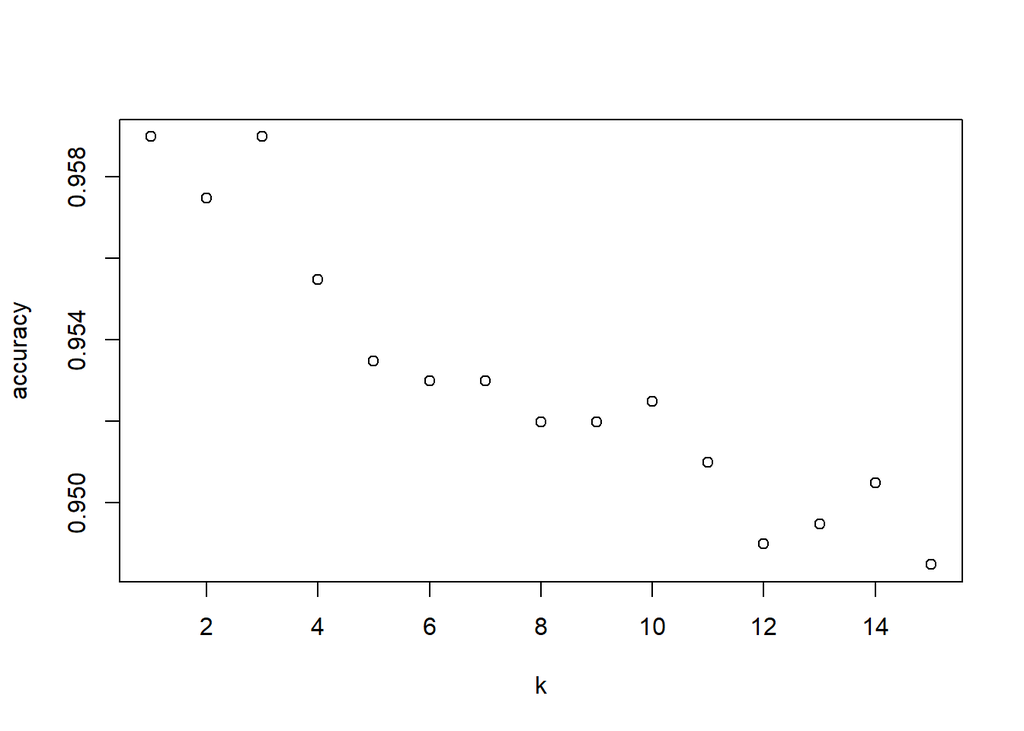

```r
plot(accuracy.df)
```

Both k=1 and k=3 get the highest accuracy, in case of the overfit(k is too small), I choose k = 3.

# Confusion matrix for k=3

Here i use the best k value which is 3.

```r
knn.pred.2 <- knn(Train_data_norm[,-8], Validation_data_norm[,-8],  # 8 column is personal loan
                cl = Train_data_norm[,8], k=3)

Validation_data_norm[,8] = data.frame(Validation_data_norm[,8])
outcome.comparison.2 <- data.frame(knn.pred.2, Validation_data_norm[,8])  # put the predicted and observed data into data.frame
names(outcome.comparison.2) <- c("Predicted", "Observed")
head(outcome.comparison.2)
```

```
##   Predicted Observed
## 1         0        0
## 2         0        0
## 3         0        0
## 4         0        0
## 5         1        0
## 6         0        0
```

```r
#confusion matrix
CrossTable(x = outcome.comparison.2$Observed, y = outcome.comparison.2$Predicted, prop.chisq = FALSE)
```

```
##
##
##    Cell Contents
## |-------------------------|
## |                       N |
## |           N / Row Total |
## |           N / Col Total |
## |         N / Table Total |
## |-------------------------|
##
##
## Total Observations in Table:  1999
##
##
##                               | outcome.comparison.2$Predicted
## outcome.comparison.2$Observed |         0 |         1 | Row Total |
## ------------------------------|-----------|-----------|-----------|
##                             0 |      1795 |         5 |      1800 |
##                               |     0.997 |     0.003 |     0.900 |
##                               |     0.959 |     0.039 |           |
##                               |     0.898 |     0.003 |           |
## ------------------------------|-----------|-----------|-----------|
##                             1 |        77 |       122 |       199 |
##                               |     0.387 |     0.613 |     0.100 |
##                               |     0.041 |     0.961 |           |
##                               |     0.039 |     0.061 |           |
## ------------------------------|-----------|-----------|-----------|
##                  Column Total |      1872 |       127 |      1999 |
##                               |     0.936 |     0.064 |           |
## ------------------------------|-----------|-----------|-----------|
##
##
```

A total of 77 + 5 = 82 misclassification cases.

Different error types K = 3: False positive : 5 False negative : 77 Total number : 1999 Accuracy = (1795 + 122) / 1999 = 0.959

## Classify new customer with the model when k = 3

```r
mytest <- Train_data_norm[1,-8]   #create format for the test sample
mytest[1,] <- c(40,10,84,2,2,2,0,0,0,1,1)  #input the sample data
mytest_norm <- mytest
mytest_norm[,c(1:3,5,7)] <- predict(z.norm, mytest[,c(1:3,5,7)])  # nomralize the sample data
mytest_norm
```

```
##          Age Experience    Income Family      CCAvg Education   Mortgage
## 2 -0.4638335  -0.883519 0.2211196      2 0.03813638         2 -0.5557052
##   Securities.Account CD.Account Online CreditCard
## 2                  0          0      1          1
```

```r
knn.test.pred.2 <- knn(Train_data_norm[,-8], mytest_norm,
                     cl = Train_data_norm[,8], k=3, prob = TRUE)
knn.test.pred.2
```

```
## [1] 0
## attr(,"prob")
## [1] 1
## Levels: 0 1
```

The outcome shows “0” which means this customer cannot accept the personal loan.

## Repartition data into Train 50%, Validation 30% and Test 20%

```r
set.seed(123)
Test_index = createDataPartition(my_bank_data$Age, p=0.2, list=FALSE)  # 20% reserved for test
Test_data = my_bank_data[Test_index,]
TraVal_data = my_bank_data[-Test_index,] # Training and validation is rest
Train_index_new = createDataPartition(TraVal_data$Age, p=0.625, list=FALSE) # 75% of remaining is training
Train_data_new = TraVal_data[Train_index_new,]
Validation_data_new = TraVal_data[-Train_index_new,]   # the rest is validation
summary(Train_data_new)
```

```
##       Age          Experience       Income       Family      CCAvg
##  Min.   :23.00   Min.   :-3.0   Min.   :  8.00   1:730   Min.   : 0.000
##  1st Qu.:35.00   1st Qu.:10.0   1st Qu.: 39.00   2:647   1st Qu.: 0.700
##  Median :45.00   Median :20.0   Median : 64.00   3:507   Median : 1.600
##  Mean   :45.34   Mean   :20.1   Mean   : 73.88   4:617   Mean   : 1.961
##  3rd Qu.:55.00   3rd Qu.:30.0   3rd Qu.: 99.00           3rd Qu.: 2.600
##  Max.   :67.00   Max.   :43.0   Max.   :224.00           Max.   :10.000
##  Education    Mortgage      Personal.Loan Securities.Account CD.Account
##  1:1058    Min.   :  0.00   0:2264        0:2228             0:2357
##  2: 706    1st Qu.:  0.00   1: 237        1: 273             1: 144
##  3: 737    Median :  0.00
##            Mean   : 55.99
##            3rd Qu.:102.00
##            Max.   :587.00
##  Online   CreditCard
##  0:1030   0:1775
##  1:1471   1: 726
##
##
##
##
```

```r
summary(Validation_data_new)
```

```
##       Age          Experience        Income       Family      CCAvg
##  Min.   :23.00   Min.   :-2.00   Min.   :  8.00   1:413   Min.   : 0.000
##  1st Qu.:35.00   1st Qu.:10.00   1st Qu.: 39.00   2:393   1st Qu.: 0.700
##  Median :45.00   Median :20.00   Median : 63.00   3:308   Median : 1.550
##  Mean   :45.31   Mean   :20.06   Mean   : 73.12   4:384   Mean   : 1.922
##  3rd Qu.:55.00   3rd Qu.:29.00   3rd Qu.: 94.00           3rd Qu.: 2.500
##  Max.   :67.00   Max.   :43.00   Max.   :204.00           Max.   :10.000
##  Education    Mortgage      Personal.Loan Securities.Account CD.Account Online
##  1:615     Min.   :  0.00   0:1344        0:1348             0:1410     0:591
##  2:417     1st Qu.:  0.00   1: 154        1: 150             1:  88     1:907
##  3:466     Median :  0.00
##            Mean   : 56.44
##            3rd Qu.:101.75
##            Max.   :612.00
##  CreditCard
##  0:1056
##  1: 442
##
##
##
##
```

```r
summary(Test_data)
```

```
##       Age          Experience        Income       Family      CCAvg
##  Min.   :23.00   Min.   :-2.00   Min.   :  8.00   1:329   Min.   : 0.000
##  1st Qu.:35.00   1st Qu.:10.00   1st Qu.: 38.00   2:256   1st Qu.: 0.700
##  Median :45.00   Median :20.00   Median : 64.00   3:195   Median : 1.500
##  Mean   :45.38   Mean   :20.16   Mean   : 74.49   4:221   Mean   : 1.905
##  3rd Qu.:55.00   3rd Qu.:30.00   3rd Qu.:101.00           3rd Qu.: 2.500
##  Max.   :67.00   Max.   :41.00   Max.   :203.00           Max.   :10.000
##  Education    Mortgage      Personal.Loan Securities.Account CD.Account Online
##  1:423     Min.   :  0.00   0:912         0:902              0:931      0:395
##  2:280     1st Qu.:  0.00   1: 89         1: 99              1: 70      1:606
##  3:298     Median :  0.00
##            Mean   : 57.87
##            3rd Qu.: 98.00
##            Max.   :635.00
##  CreditCard
##  0:699
##  1:302
##
##
##
##
```

## Normalize the new partition data

```r
#copy the data
Train_data_norm_new <- Train_data_new
Validation_data_norm_new <- Validation_data_new
Test_data_norm <- Test_data
#z normalize the data
z.norm.new <- preProcess(Train_data_new[,c(1:3,5,7)], method=c("center", "scale"))
Train_data_norm_new[,c(1:3,5,7)] <- predict(z.norm.new, Train_data_new[,c(1:3,5,7)])
Validation_data_norm_new[,c(1:3,5,7)] <- predict(z.norm.new, Validation_data_new[,c(1:3,5,7)])
Test_data_norm[,c(1:3,5,7)] <- predict(z.norm.new, Test_data[,c(1:3,5,7)])
summary(Train_data_norm_new)
```

```
##       Age             Experience            Income        Family
##  Min.   :-1.94399   Min.   :-2.010880   Min.   :-1.4333   1:730
##  1st Qu.:-0.89978   1st Qu.:-0.879429   1st Qu.:-0.7589   2:647
##  Median :-0.02961   Median :-0.009083   Median :-0.2150   3:507
##  Mean   : 0.00000   Mean   : 0.000000   Mean   : 0.0000   4:617
##  3rd Qu.: 0.84057   3rd Qu.: 0.861264   3rd Qu.: 0.5464
##  Max.   : 1.88478   Max.   : 1.992714   Max.   : 3.2659
##      CCAvg         Education    Mortgage       Personal.Loan Securities.Account
##  Min.   :-1.1124   1:1058    Min.   :-0.5580   0:2264        0:2228
##  1st Qu.:-0.7153   2: 706    1st Qu.:-0.5580   1: 237        1: 273
##  Median :-0.2047   3: 737    Median :-0.5580
##  Mean   : 0.0000             Mean   : 0.0000
##  3rd Qu.: 0.3627             3rd Qu.: 0.4586
##  Max.   : 4.5611             Max.   : 5.2927
##  CD.Account Online   CreditCard
##  0:2357     0:1030   0:1775
##  1: 144     1:1471   1: 726
##
##
##
##
```

```r
var(Train_data_norm_new[,c(1:3,5,7)])
```

```
##                     Age   Experience      Income       CCAvg     Mortgage
## Age         1.000000000  0.994306511 -0.09169008 -0.06363286 -0.008350283
## Experience  0.994306511  1.000000000 -0.08178660 -0.05897816 -0.004302765
## Income     -0.091690081 -0.081786601  1.00000000  0.65664311  0.190331025
## CCAvg      -0.063632860 -0.058978157  0.65664311  1.00000000  0.097722268
## Mortgage   -0.008350283 -0.004302765  0.19033102  0.09772227  1.000000000
```

```r
summary(Validation_data_norm_new)
```

```
##       Age              Experience            Income         Family
##  Min.   :-1.943995   Min.   :-1.923845   Min.   :-1.43329   1:413
##  1st Qu.:-0.899784   1st Qu.:-0.879429   1st Qu.:-0.75888   2:393
##  Median :-0.029609   Median :-0.009083   Median :-0.23675   3:308
##  Mean   :-0.002597   Mean   :-0.003447   Mean   :-0.01664   4:384
##  3rd Qu.: 0.840566   3rd Qu.: 0.774229   3rd Qu.: 0.43766
##  Max.   : 1.884777   Max.   : 1.992714   Max.   : 2.83075
##      CCAvg          Education    Mortgage         Personal.Loan
##  Min.   :-1.11244   1:615     Min.   :-0.558010   0:1344
##  1st Qu.:-0.71529   2:417     1st Qu.:-0.558010   1: 154
##  Median :-0.23304   3:466     Median :-0.558010
##  Mean   :-0.02214             Mean   : 0.004552
##  3rd Qu.: 0.30594             3rd Qu.: 0.456142
##  Max.   : 4.56109             Max.   : 5.541857
##  Securities.Account CD.Account Online  CreditCard
##  0:1348             0:1410     0:591   0:1056
##  1: 150             1:  88     1:907   1: 442
##
##
##
##
```

```r
var(Validation_data_norm_new[,c(1:3,5,7)])
```

```
##                     Age   Experience       Income        CCAvg    Mortgage
## Age         0.989903878  0.986330443 -0.005704109 -0.009374315 0.007025122
## Experience  0.986330443  0.994523409  0.001027814 -0.009567017 0.005727089
## Income     -0.005704109  0.001027814  0.985795443  0.621780246 0.241380077
## CCAvg      -0.009374315 -0.009567017  0.621780246  0.938075405 0.158530892
## Mortgage    0.007025122  0.005727089  0.241380077  0.158530892 1.030080037
```

```r
summary(Test_data_norm)
```

```
##       Age              Experience            Income         Family
##  Min.   :-1.943995   Min.   :-1.923845   Min.   :-1.43329   1:329
##  1st Qu.:-0.899784   1st Qu.:-0.879429   1st Qu.:-0.78063   2:256
##  Median :-0.029609   Median :-0.009083   Median :-0.21500   3:195
##  Mean   : 0.003077   Mean   : 0.005264   Mean   : 0.01314   4:221
##  3rd Qu.: 0.840566   3rd Qu.: 0.861264   3rd Qu.: 0.58995
##  Max.   : 1.884777   Max.   : 1.818645   Max.   : 2.80899
##      CCAvg          Education    Mortgage        Personal.Loan
##  Min.   :-1.11244   1:423     Min.   :-0.55801   0:912
##  1st Qu.:-0.71529   2:280     1st Qu.:-0.55801   1: 89
##  Median :-0.26141   3:298     Median :-0.55801
##  Mean   :-0.03152             Mean   : 0.01876
##  3rd Qu.: 0.30594             3rd Qu.: 0.41877
##  Max.   : 4.56109             Max.   : 5.77110
##  Securities.Account CD.Account Online  CreditCard
##  0:902              0:931      0:395   0:699
##  1: 99              1: 70      1:606   1:302
##
##
##
##
```

```r
var(Test_data_norm[,c(1:3,5,7)])
```

```
##                    Age  Experience      Income       CCAvg    Mortgage
## Age         0.99209622  0.98593128 -0.03834259 -0.08402641 -0.05307091
## Experience  0.98593128  0.99126673 -0.02995515 -0.08592732 -0.05141666
## Income     -0.03834259 -0.02995515  1.03749370  0.63428182  0.21226492
## CCAvg      -0.08402641 -0.08592732  0.63428182  1.00956632  0.07106302
## Mortgage   -0.05307091 -0.05141666  0.21226492  0.07106302  1.09556067
```

## Compare confusion matrix

compare the confusion matrix of the test set with the training and validation sets. 1. test with train 2. test with validation

```r
# 1. Test with Train
knn.pred.new1 <- knn(Train_data_norm_new[,-8],Test_data_norm[,-8],  # 8 column is personal loan
                cl = Train_data_norm_new[,8], k=3)

# model Evaluation
Test_data_norm[,8] = data.frame(Test_data_norm[,8])
Test_with_Train <- data.frame(knn.pred.new1, Test_data_norm[,8])
names(Test_with_Train) <- c("Predicted", "Observed")
head(Test_with_Train)
```

```
##   Predicted Observed
## 1         0        0
## 2         0        0
## 3         0        0
## 4         0        0
## 5         0        0
## 6         0        0
```

```r
#confusion matrix
CrossTable(x = Test_with_Train$Observed, y = Test_with_Train$Predicted, prop.chisq = FALSE)
```

```
##
##
##    Cell Contents
## |-------------------------|
## |                       N |
## |           N / Row Total |
## |           N / Col Total |
## |         N / Table Total |
## |-------------------------|
##
##
## Total Observations in Table:  1001
##
##
##                          | Test_with_Train$Predicted
## Test_with_Train$Observed |         0 |         1 | Row Total |
## -------------------------|-----------|-----------|-----------|
##                        0 |       911 |         1 |       912 |
##                          |     0.999 |     0.001 |     0.911 |
##                          |     0.965 |     0.018 |           |
##                          |     0.910 |     0.001 |           |
## -------------------------|-----------|-----------|-----------|
##                        1 |        33 |        56 |        89 |
##                          |     0.371 |     0.629 |     0.089 |
##                          |     0.035 |     0.982 |           |
##                          |     0.033 |     0.056 |           |
## -------------------------|-----------|-----------|-----------|
##             Column Total |       944 |        57 |      1001 |
##                          |     0.943 |     0.057 |           |
## -------------------------|-----------|-----------|-----------|
##
##
```

```r
# 2. Test with Validation
knn.pred.new2 <- knn(Validation_data_norm_new[,-8],Test_data_norm[,-8],  # 8 column is personal loan
                cl = Validation_data_norm_new[,8], k=3)

# model Evaluation
Test_data_norm[,8] = data.frame(Test_data_norm[,8])
Test_with_Validation <- data.frame(knn.pred.new2, Test_data_norm[,8])
names(Test_with_Validation) <- c("Predicted", "Observed")
head(Test_with_Validation)
```

```
##   Predicted Observed
## 1         0        0
## 2         0        0
## 3         0        0
## 4         0        0
## 5         0        0
## 6         0        0
```

```r
#confusion matrix
CrossTable(x = Test_with_Validation$Observed, y = Test_with_Validation$Predicted, prop.chisq = FALSE)
```

```
##
##
##    Cell Contents
## |-------------------------|
## |                       N |
## |           N / Row Total |
## |           N / Col Total |
## |         N / Table Total |
## |-------------------------|
##
##
## Total Observations in Table:  1001
##
##
##                               | Test_with_Validation$Predicted
## Test_with_Validation$Observed |         0 |         1 | Row Total |
## ------------------------------|-----------|-----------|-----------|
##                             0 |       909 |         3 |       912 |
##                               |     0.997 |     0.003 |     0.911 |
##                               |     0.963 |     0.053 |           |
##                               |     0.908 |     0.003 |           |
## ------------------------------|-----------|-----------|-----------|
##                             1 |        35 |        54 |        89 |
##                               |     0.393 |     0.607 |     0.089 |
##                               |     0.037 |     0.947 |           |
##                               |     0.035 |     0.054 |           |
## ------------------------------|-----------|-----------|-----------|
##                  Column Total |       944 |        57 |      1001 |
##                               |     0.943 |     0.057 |           |
## ------------------------------|-----------|-----------|-----------|
##
##
```

Comment : 1. Test with Train : True positive = 56 True negative = 911 Accuracy = (56 + 911) / 1001 = 0.966 2. Test with Validation : True positive = 54 True negative = 909 Accuracy = (54 + 909) / 1001 = 0.962 The accuracy for test with train is higher than test with validation. Reason : We use training set to normalize validation and test sets. So when we predict the test set with train data, the accuracy is higher than the predicted test set using the validation set.